# Trabajo Final. Geoinformática 2019-2020

Fernanda Gaytán Camarillo y Janet Milanez Figueroa

26 de agosto de 2020

# Patrones Puntuales

Adicional al análisis de la base de datos que contiene las emisiones totales, tenemos esta base de datos con datos puntuales de las fuentes fijas. Esta base se trata de puntos donde se encuentran las fuentes fijas que anualmente reportan a SEDEMA las emisiones que producen, y se clasifican en fuentes fijas de COMERCIO, de INDUSTRIA o de SERVICIO.

Por medio de un análisis de patrones puntuales queremos saber si se presenta algún patrón de agrupación o no en alguno de estos tres rubros, lo cual nos permitirá ver la saturación de fuentes fijas que existen en la Zona Metropolitana del Valle de México

## Librerías

```r
library(spatstat) # Análisis de patrones puntuales
library(rgdal) # Leer datos espaciales
library(rgeos) # funciones de geoprocesamiento
library(sp) # crear a partir de coordenadas un objeto de clase spatial
library(maptools) #tiene funciones que forzan la transformación entre objetos de clase sp y owin
```

#### Importar shapefiles de fuentes fijas: comercio, industria y servicios

Shape de puntos a objeto point pattern process de las tres fuentes fijas

```
- Comercio
```

```r
SC <- readShapePoints("comercio.shp")
SPC <- as(SC, "SpatialPoints")
RCOM <- as(SPC, "ppp")
```

```
- Industria
```

```r
SI <- readShapePoints("industria.shp")
SPI <- as(SI, "SpatialPoints")
RIND <- as(SPI, "ppp")
```

```
- Servicio
```

```r
SS <- readShapePoints("servicio.shp")
SPS <- as(SS, "SpatialPoints")
RSER <- as(SPS, "ppp")
```

#### Área de estudio

Vamos a utilizar el shape de la Zona Metropolitana del Valle de México como ventana de estudio para poder reaizar nuestro análisis de patrones puntuales.

```r
#Shape dissolve agebspasa a calseowin
S <- readOGR("zmvm.shp")
env <- gUnaryUnion(S)
W <- as(env, "owin")
#Se sustituye la ventanaporagebs-dissolve en cada tipo de robo
RCOM<- RCOM[W]
RIND<- RIND[W]
RSER<- RSER[W]
```

#### Visualización de los datos

```r
par(mfrow=c(1,3))
plot(S)+ points(RCOM, col="red")
```

```
## integer(0)
```

```r
plot(S)+ points(RIND, col="red")
```

```
## integer(0)
```

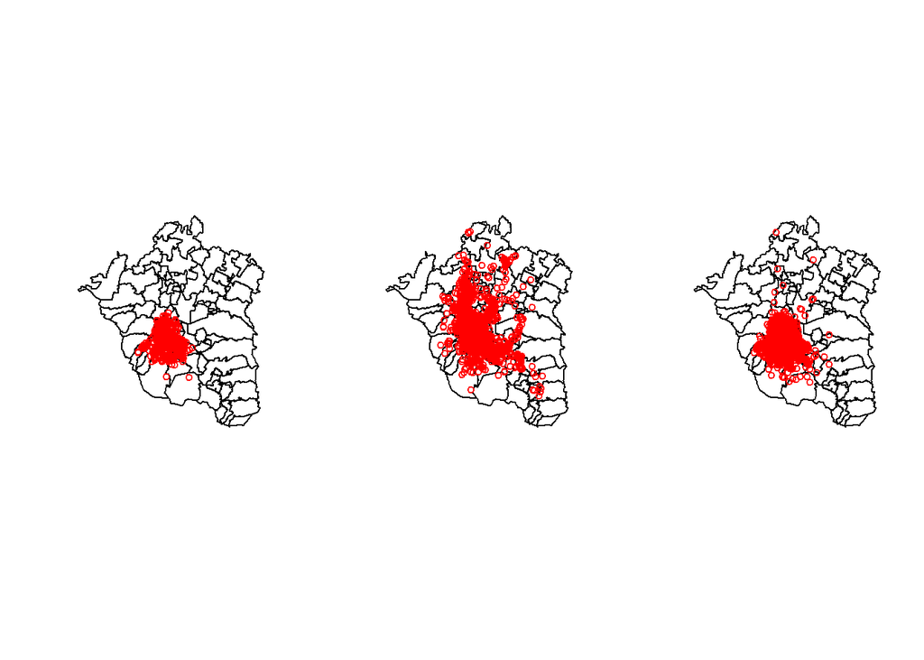

```
## integer(0)
```

```r
plot(S)+ points(RSER, col="red")
```

#### Evaluar el tipo de patron puntual

Para evaluar el tipo de patron puntual que están presentando las diferentes fuentes fijas vamos a utilizar la Función Gest, que es la del vecino más cercano. En esta se usa la intensidad del fenómeno para hacer las simulaciones del modelo. El patrón teórico se obtiene a partir de la distribución aleatoria dada la intensidad medida, mientras que el patrón observado muestra la distribución de los puntos reales. Con esto podemos determinar tres posibles casos:

1. Patrón aleatorio: Que el patrón observado se encuentra dentro de la nube de simulaciones
2. Patrón agrupado: Que el patrón observado se encuentra por encima de la nube de simulaciones
3. Patrón disperso: Que el patrón observado se encuentra por debajo de la nube de simulaciones

   -**Función G**:

```r
par(mfrow=c(1,3))
envzmvm1<- envelope(RCOM, fun=Gest, nrank=2, nsim=99)
```

```
## Generating 99 simulations of CSR  ...
## 1, 2, 3, 4, 5, 6, 7, 8, 9, 10, 11, 12, 13, 14, 15, 16, 17, 18, 19, 20, 21, 22, 23, 24, 25, 26, 27, 28, 29, 30, 31, 32, 33, 34, 35, 36, 37, 38,
## 39, 40, 41, 42, 43, 44, 45, 46, 47, 48, 49, 50, 51, 52, 53, 54, 55, 56, 57, 58, 59, 60, 61, 62, 63, 64, 65, 66, 67, 68, 69, 70, 71, 72, 73, 74, 75, 76,
## 77, 78, 79, 80, 81, 82, 83, 84, 85, 86, 87, 88, 89, 90, 91, 92, 93, 94, 95, 96, 97, 98,  99.
##
## Done.
```

```r
plot(envzmvm1, main="G obs vs G teo para COMERCIO")
envzmvm2<- envelope(RIND, fun=Gest, nrank=2, nsim=99)
```

```
## Generating 99 simulations of CSR  ...
## 1, 2, 3, 4, 5, 6, 7, 8, 9, 10, 11, 12, 13, 14, 15, 16, 17, 18, 19, 20, 21, 22, 23, 24, 25, 26, 27, 28, 29, 30, 31, 32, 33, 34, 35, 36, 37, 38,
## 39, 40, 41, 42, 43, 44, 45, 46, 47, 48, 49, 50, 51, 52, 53, 54, 55, 56, 57, 58, 59, 60, 61, 62, 63, 64, 65, 66, 67, 68, 69, 70, 71, 72, 73, 74, 75, 76,
## 77, 78, 79, 80, 81, 82, 83, 84, 85, 86, 87, 88, 89, 90, 91, 92, 93, 94, 95, 96, 97, 98,  99.
##
## Done.
```

```r
plot(envzmvm2, main="G obs vs G teo para INDUSTRIA")
envzmvm3<- envelope(RSER, fun=Gest, nrank=2, nsim=99)
```

```
## Generating 99 simulations of CSR  ...
## 1, 2, 3, 4, 5, 6, 7, 8, 9, 10, 11, 12, 13, 14, 15, 16, 17, 18, 19, 20, 21, 22, 23, 24, 25, 26, 27, 28, 29, 30, 31, 32, 33, 34, 35, 36, 37, 38,
## 39, 40, 41, 42, 43, 44, 45, 46, 47, 48, 49, 50, 51, 52, 53, 54, 55, 56, 57, 58, 59, 60, 61, 62, 63, 64, 65, 66, 67, 68, 69, 70, 71, 72, 73, 74, 75, 76,
## 77, 78, 79, 80, 81, 82, 83, 84, 85, 86, 87, 88, 89, 90, 91, 92, 93, 94, 95, 96, 97, 98,  99.
##
## Done.
```

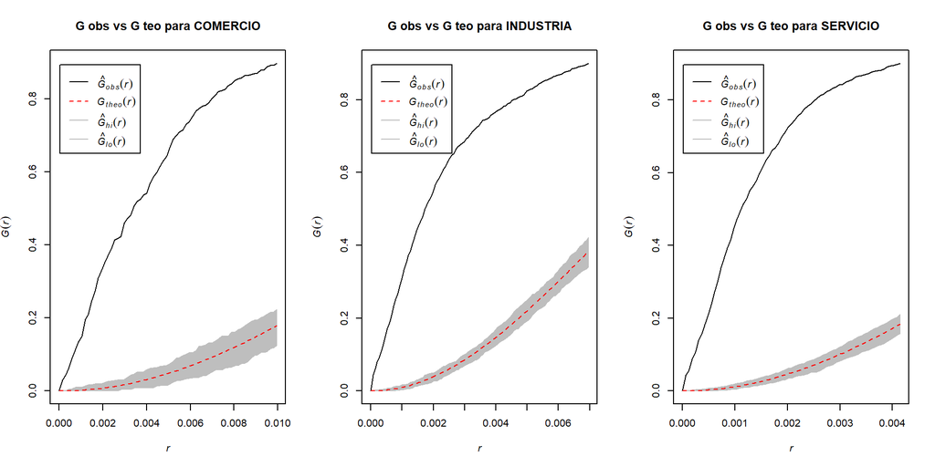

```r
plot(envzmvm3, main="G obs vs G teo para SERVICIO")
```

Basado en el cálculo de las funciones existen **patrones puntuales de agregación en los tres tipos de fuentes fijas**. Esto aporta mucho a nuestra investigación porque es probable que la mejor estrategia para reducir las altas concentraciones de contaminantes sea controlar el nuevo desarrollo de industrias, comercios y servicios en zonas donde la concentración ya es demsiada por otras fuentes (como las fuentes móviles, que son las que más emisiones producen). Es por ello que haremos un mapa de densidad de Kernel para ver exactamente dónde se está presentando esa concentración de fuentes fijas.

```
- __Estimación del Kernel__:
```

```r
bwc<- bw.diggle(RCOM)
bwc<- as.numeric(bwc)
bwc
```

```
## [1] 0.009273196
```

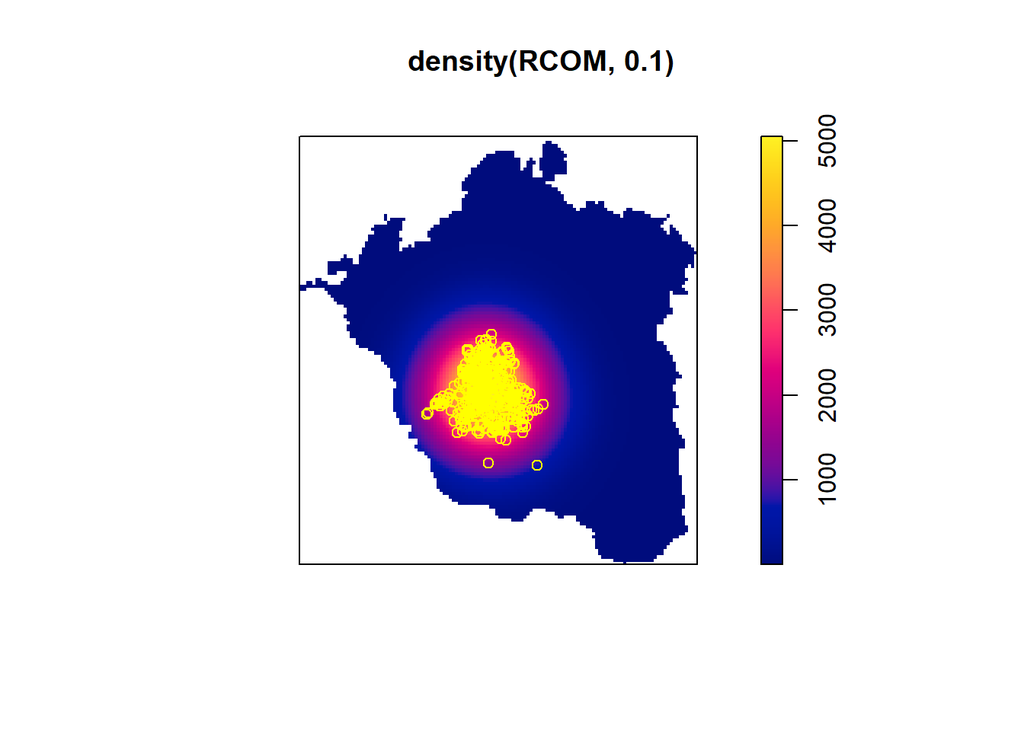

```r
plot(density(RCOM,0.1))
points(RCOM, col="yellow", pch=1)
```

**Decidí aumentar el ancho de banda para que fueran más evidentes los hotspots, en lugar de 0.009 que era el calculado con la función, le puse 0.1.**

```r
bwi<- bw.diggle(RIND)
bwi<- as.numeric(bwi)
bwi
```

```
## [1] 0.002833477
```

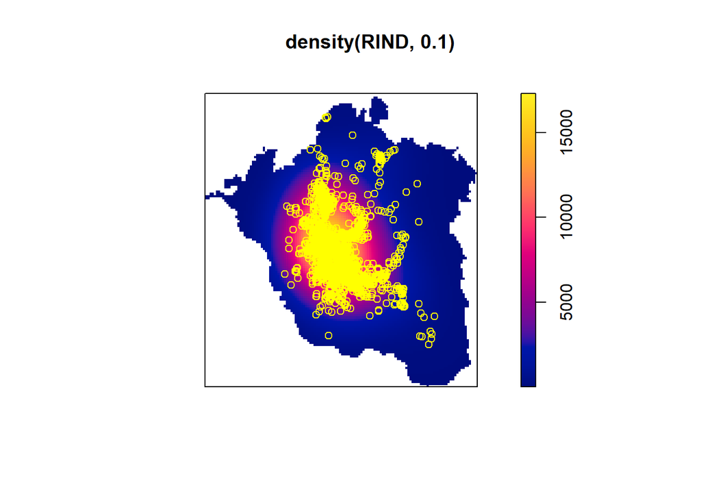

```r
plot(density(RIND,0.1))
points(RIND, col="yellow", pch=1)
```

**Decidí aumentar el ancho de banda para que fueran más evidentes los hotspots, en lugar de 0.002 que era el calculado con la función, le puse 0.1.**

```r
bws<- bw.diggle(RSER)
bws<- as.numeric(bws)
bws
```

```
## [1] 0.001803121
```

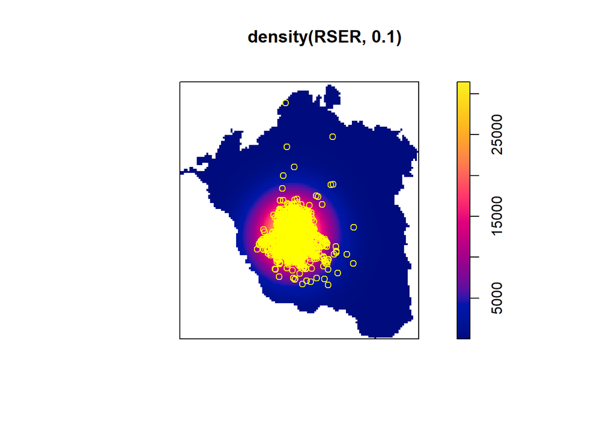

```r
plot(density(RSER,0.1))
points(RSER, col="yellow", pch=1)
```

**Decidí aumentar el ancho de banda para que fueran más evidentes los hotspots, en lugar de 0.001 que era el calculado con la función, le puse 0.1.**